# MPDW Pertemuan 4

Ibrahim Zaidan

2025-09-24

# 1 White Noise

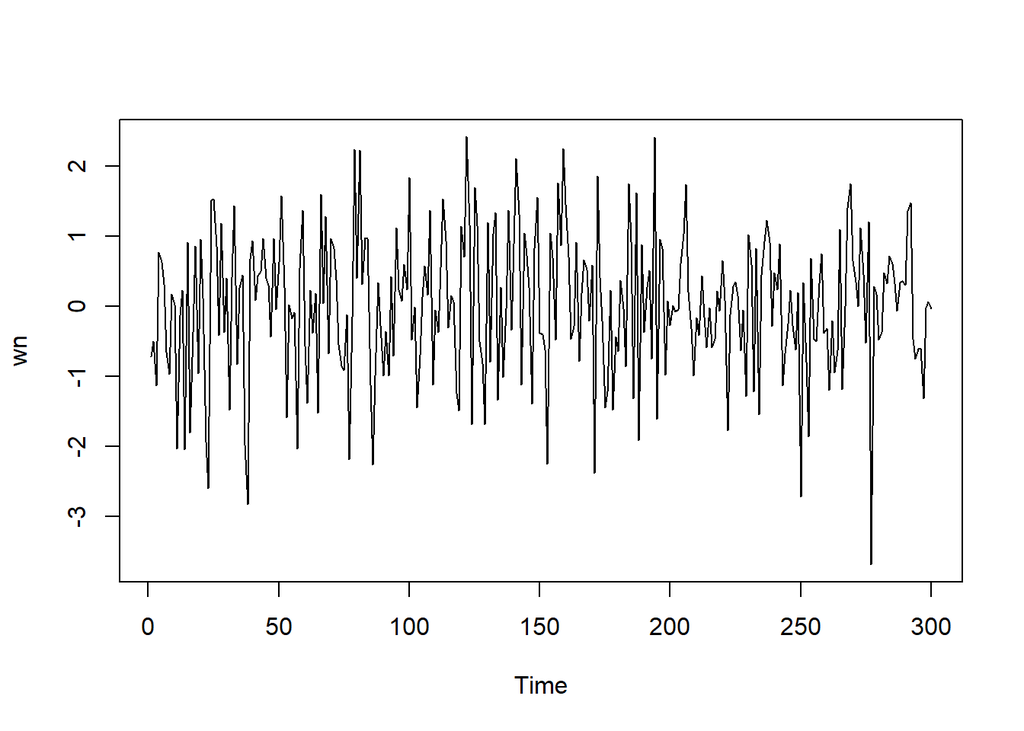

```r
set.seed(140305)
wn <- rnorm(300)
ts.plot(wn)
```

```r
ma <- numeric(300)
```

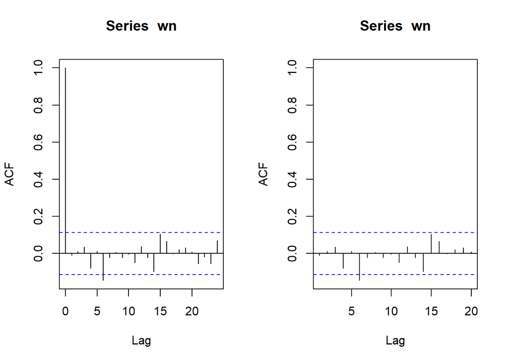

```r
par(mfrow = c(1, 2))
acf(wn)
acf(wn, xlim = c(1, 20))
```

# 2 MA

## 2.1 Pembangkitan MA(2)

Akan dibangkitkan model MA(2) dengan $\theta_1 = 0,4$ dan $\theta_2 = 0,6$ sebanyak 300 data

### 2.1.1 Manual

```r
set.seed(140305)
ma[1:2] <- wn[1:2]
```

```r
for(i in 3:300){
   ma[i] <- wn[i] + 0.4 * wn[i - 1] + 0.6 * wn[i - 2]
}
ma
```

```
##   [1] -0.715449656 -0.500878274 -1.755014127  0.020592285  0.261903966
##   [6]  1.029214054 -0.148116267 -1.033505354 -0.601096907 -0.479381836
##  [11] -1.912682552 -0.916812168 -1.032761821 -2.017376629  0.245854470
##  [16] -2.656138767 -0.535003585 -0.364977499 -0.826785198  1.091841075
##  [21] -0.072015623 -1.313344171 -3.298940034 -0.684937712  0.581829976
##  [26]  2.387156188  0.860922410  1.547623577 -0.131607507  0.978945868
##  [31] -1.533487353  0.073977599  0.715506177  0.002556006  0.800661683
##  [36]  0.057653561 -1.632392939 -3.349869163 -1.632981599 -0.488525614
##  [41]  0.871382023  1.036240253  0.730714736  1.435391023  1.093778011
##  [46]  1.052313271 -0.064364617  0.985545633  0.094774024  1.203266466
##  [51]  1.813406127  1.282993823 -0.527784627 -0.451938668 -1.117539326
##  [56] -0.145419449 -2.165281061 -0.315106277  0.381101285  0.312734761
##  [61] -0.775519247 -0.657694308 -1.112729691  0.176241351 -1.668804497
##  [66]  1.113077276 -0.220706722  2.273006529 -0.131824932  1.473142333
##  [71]  0.807661534  1.291082295  0.106852907 -0.829172024 -1.572090307
```

[output cut: 45 more lines]

### 2.1.2 Menggunakan `arima.sim`

```r
ma_sim <- arima.sim(list(order=c(0,0,2), ma=c(0.4, 0.6)), n=300)
ma_sim
```

```
## Time Series:
## Start = 1
## End = 300
## Frequency = 1
##   [1] -1.755014127  0.020592285  0.261903966  1.029214054 -0.148116267
##   [6] -1.033505354 -0.601096907 -0.479381836 -1.912682552 -0.916812168
##  [11] -1.032761821 -2.017376629  0.245854470 -2.656138767 -0.535003585
##  [16] -0.364977499 -0.826785198  1.091841075 -0.072015623 -1.313344171
##  [21] -3.298940034 -0.684937712  0.581829976  2.387156188  0.860922410
##  [26]  1.547623577 -0.131607507  0.978945868 -1.533487353  0.073977599
##  [31]  0.715506177  0.002556006  0.800661683  0.057653561 -1.632392939
##  [36] -3.349869163 -1.632981599 -0.488525614  0.871382023  1.036240253
##  [41]  0.730714736  1.435391023  1.093778011  1.052313271 -0.064364617
##  [46]  0.985545633  0.094774024  1.203266466  1.813406127  1.282993823
##  [51] -0.527784627 -0.451938668 -1.117539326 -0.145419449 -2.165281061
```

[output cut: 49 more lines]

## 2.2 Karakteristik MA(2)

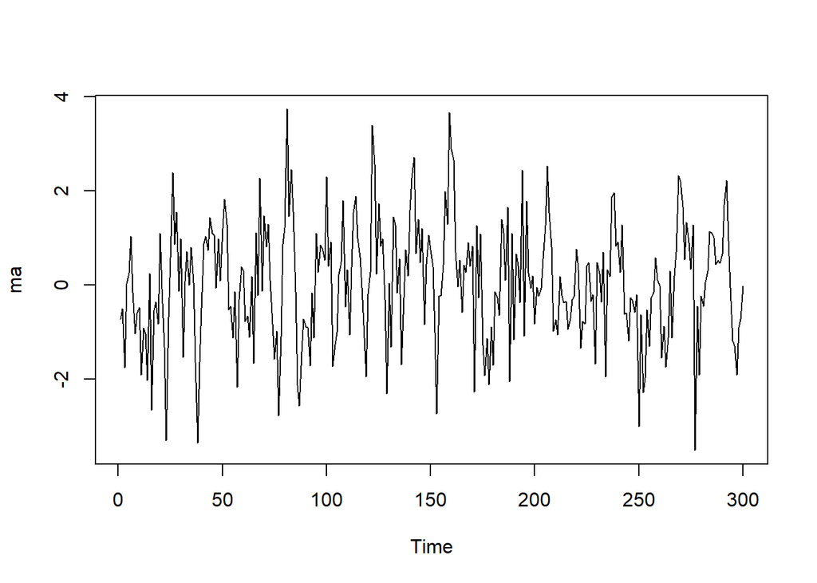

```r
ts.plot(ma)
```

Berdasarkan plot time series tersebut, terlihat bahwa model MA(2) cenderung stasioner dalam rataan.

### 2.2.1 ACF

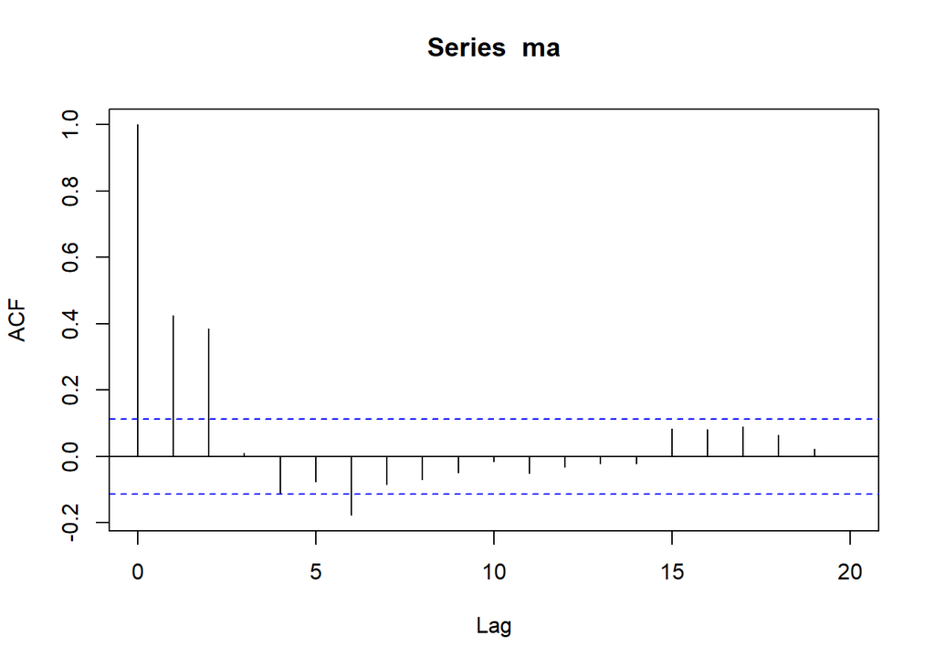

```r
acf(ma,lag.max = 20)
```

Dapat dilihar berdasarkan ACF cut-off nya di lag = 2.

### 2.2.2 PACF

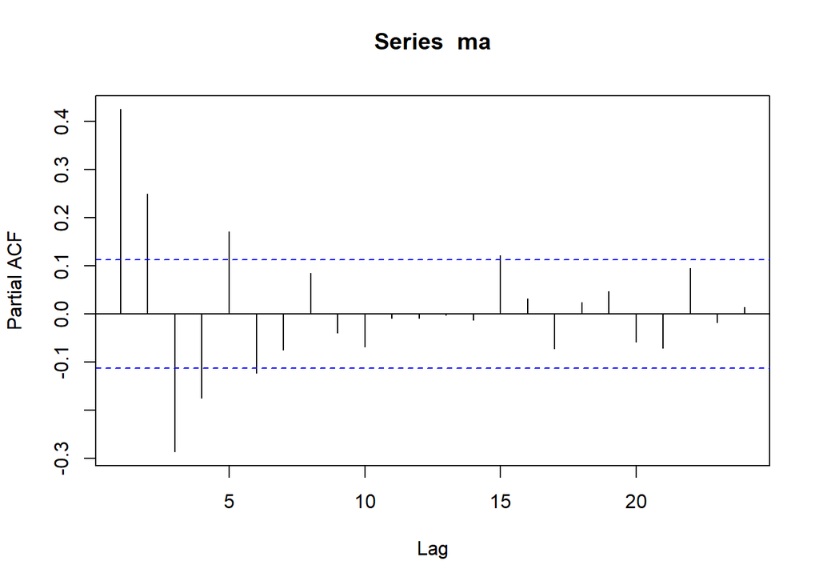

```r
pacf(ma)
```

Plot PACF tails-off menyerupai gelombang sinus

### 2.2.3 EACF

```r
TSA::eacf(ma)
```

```
## AR/MA
##   0 1 2 3 4 5 6 7 8 9 10 11 12 13
## 0 x x o o o x o o o o o  o  o  o
## 1 x x o x o x o o o o o  o  o  o
## 2 x x o x o x o o o o o  o  o  o
## 3 x x o x x x o o o o o  o  o  o
## 4 x o x o o o o o o o o  o  o  o
## 5 x o x x o o x o o o o  o  o  o
## 6 x x x x o o o o o o o  o  o  o
## 7 x x x o x o o o o o o  o  o  o
```

Segitiga yang di hasilkan adalah ketika q = 2.

## 2.3 Scatter Plot

### 2.3.1 Yt dengan Yt-1

```r
yt_ma <- ma[-1]

yt_1_ma <- ma[-300]
```

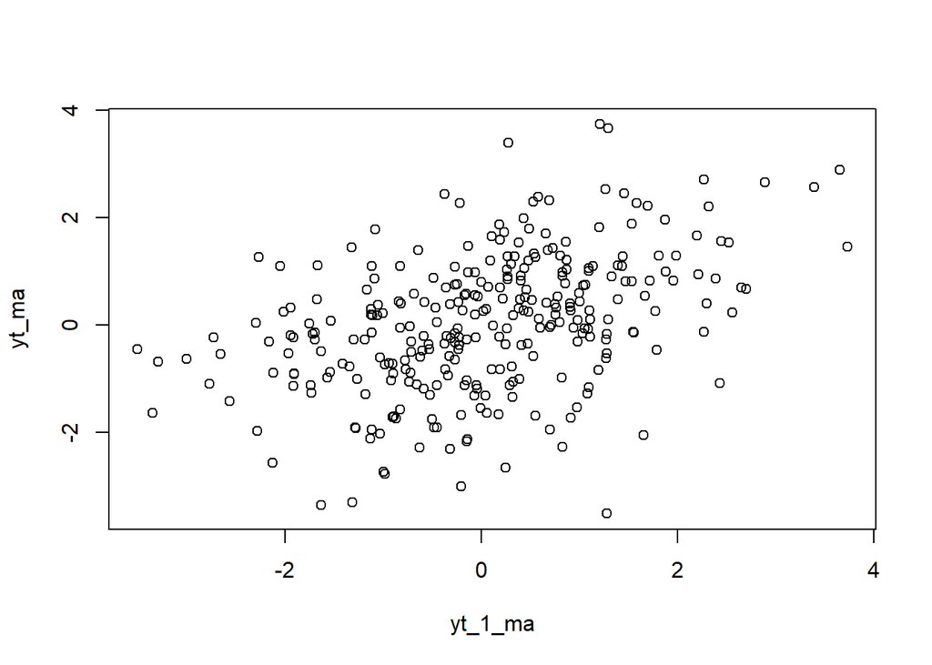

```r
plot(y=yt_ma, x=yt_1_ma)
```

### 2.3.2 Korelasi Yt dengan Yt-1

```r
cor(yt_ma,yt_1_ma)
```

```
## [1] 0.4254253
```

Dari nilai korelasi diatas diketahui bahwa ada hubungan positif antara Yt dengan Yt-1

### 2.3.3 Yt dengan Yt-2

```r
yt_ma2 <- ma[-c(1,2)]

yt_2_ma <- ma[-c(299,300)]
```

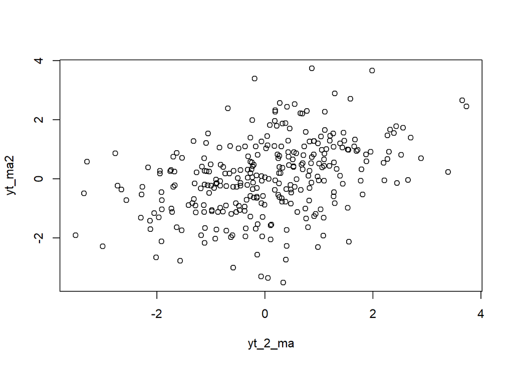

```r
plot(y=yt_ma2, x=yt_2_ma)
```

### 2.3.4 Korelasi Yt dengan Yt-2

```r
cor(yt_ma2,yt_2_ma)
```

```
## [1] 0.3857358
```

Masih ada hubungan positif antara Yt dengan Yt-2

### 2.3.5 Yt dengan Yt-3

```r
yt_ma3 <- ma[-c(1,2,3)]

yt_3_ma <- ma[-c(298,299,300)]
```

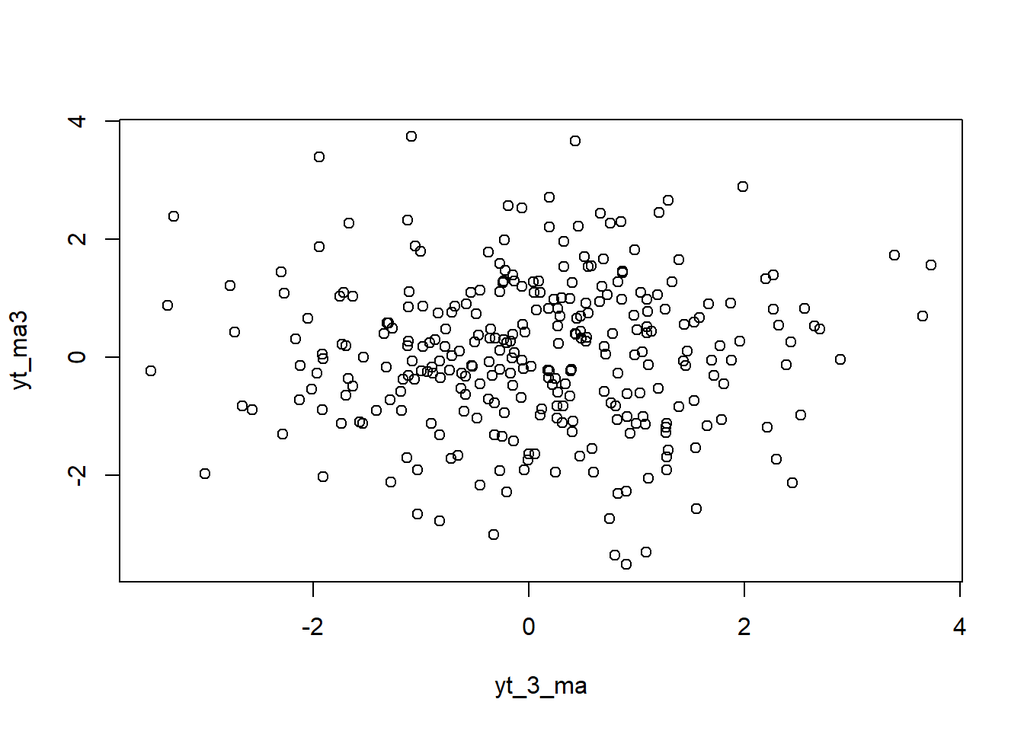

```r
plot(y=yt_ma3, x=yt_3_ma)
```

### 2.3.6 Korelasi Yt dengan Yt-3

```r
cor(yt_ma3,yt_3_ma)
```

```
## [1] 0.008561101
```

Karena nilainya makin mendekati 0, dan bila dilihat dari scatter plot nya antara Yt dengan Yt-3 tidak memiliki hubungan. Yang berarti pada MA(2), Yt berhubungan hanya sampai Yt-2 saja.

# 3 AR

## 3.1 Pembangkitan AR(2)

Akan dibangkitkan model AR(2) dengan $\phi_1 = 0,5$ dan $\phi_2 = 0,2$ sebanyak 300 data

### 3.1.1 Manual

```r
set.seed(140305)

n <- length(wn)
ar2 <- numeric(n)
ar2[1:2] <- wn[1:2]

for (i in 3:n) {
  ar2[i] <- wn[i] + 0.5*ar2[i-1] + 0.2*ar2[i-2]
}
ar2
```

```
##   [1] -0.715449656 -0.500878274 -1.518922092 -0.088360242  0.280664657
##   [6]  0.437656780 -0.376331063 -1.062620475 -0.432103407 -0.400555072
##  [11] -2.315272886 -1.359942194 -0.909764800 -2.764234976 -0.643226848
##  [16] -2.676518143 -1.833591097 -0.589167379 -1.613247833  0.030402974
##  [21] -0.190240294 -2.022183057 -3.645146891 -0.713658745  0.448235083
##  [26]  0.946893659  0.157356809  1.458670808  0.396396012  0.900274135
##  [31] -0.949561418  0.124637612  1.307553915 -0.144416567  0.458124165
##  [36]  0.644176292 -1.557571968 -3.477704423 -1.369475757 -0.444508498
##  [41] -0.407609993  0.146655635  0.493651978  1.247192276  1.126582786
##  [46]  1.120719523  0.355562080  1.374722468  0.722197208  1.270141627
##  [51]  2.361042836  1.704471416 -0.260228569  0.230757465 -0.111393588
##  [56] -0.097060587 -2.096247994 -0.519957626  0.698104868 -0.321684735
##  [61] -1.396442352 -0.530116661 -0.924920502 -0.379477629 -1.890785573
##  [66]  0.584810454 -0.039260521  1.388082553  0.010169131  1.251800992
##  [71]  1.453567915  1.356513064  0.428695303 -0.355033179 -1.003429571
```

[output cut: 45 more lines]

### 3.1.2 Menggunakan `arima.sim`

```r
ar_sim <- arima.sim(list(order=c(2,0,0), ar=c(0.5, 0.2)), n=300)
ar_sim
```

```
## Time Series:
## Start = 1
## End = 300
## Frequency = 1
##   [1]  0.946498493  0.157055556  1.458441148  0.396220931  0.900140662
##   [6] -0.949663170  0.124560041  1.307494779 -0.144461649  0.458089797
##  [11]  0.644150091 -1.557591942 -3.477719650 -1.369487365 -0.444517348
##  [16] -0.407616739  0.146650492  0.493648057  1.247189287  1.126580507
##  [21]  1.120717785  0.355560756  1.374721459  0.722196438  1.270141040
##  [26]  2.361042389  1.704471075 -0.260228829  0.230757266 -0.111393739
##  [31] -0.097060702 -2.096248081 -0.519957693  0.698104817 -0.321684774
##  [36] -1.396442381 -0.530116684 -0.924920520 -0.379477642 -1.890785583
##  [41]  0.584810446 -0.039260527  1.388082549  0.010169128  1.251800990
##  [46]  1.453567913  1.356513062  0.428695302 -0.355033180 -1.003429572
##  [51] -0.685279743 -2.725440870 -1.651770229  0.866463203  0.511620355
```

[output cut: 49 more lines]

## 3.2 Karakteristik AR(2)

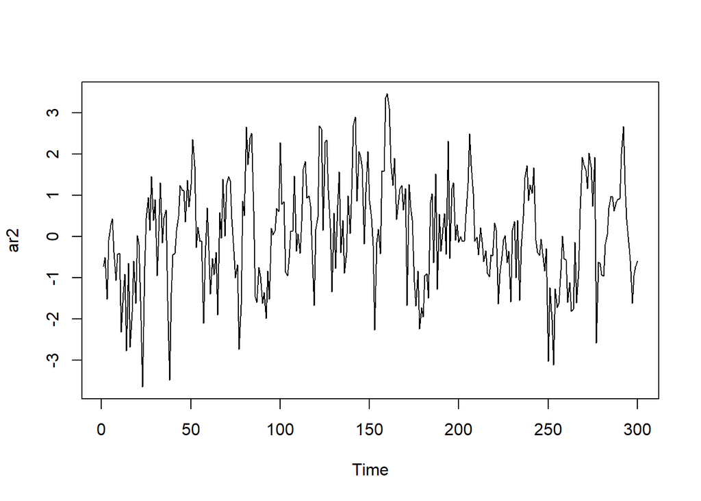

```r
ts.plot(ar2)
```

Berdasarkan plot time series tersebut, terlihat bahwa model AR(2) cenderung stasioner dalam rataan.

### 3.2.1 ACF

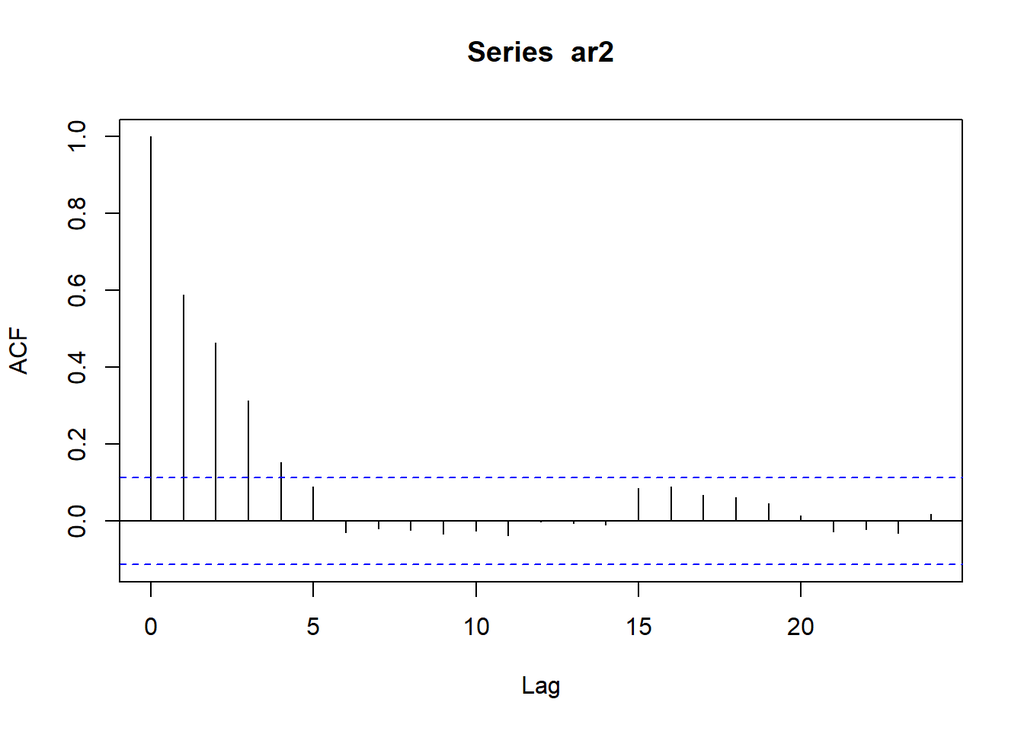

```r
acf(ar2)
```

### 3.2.2 PACF

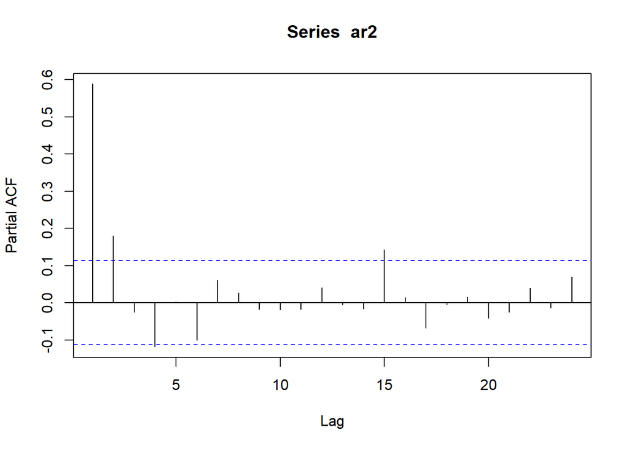

```r
pacf(ar2)
```

Plot cut-off pada lag 2, sudah sesuai dengan teori.

### 3.2.3 EACF

```r
TSA::eacf(ar2)
```

```
## AR/MA
##   0 1 2 3 4 5 6 7 8 9 10 11 12 13
## 0 x x x x o o o o o o o  o  o  o
## 1 x o x o o x o o o o o  o  o  o
## 2 x x x o x x o o o o o  o  o  o
## 3 x x x o x x o o o o o  o  o  o
## 4 o x o x o x o o o o o  o  o  o
## 5 o x x x x x o o o o o  o  o  o
## 6 x x x o x o o o o o o  o  o  o
## 7 x x x o o o o o o o o  o  o  o
```

## 3.3 Scatter Plot

### 3.3.1 Yt dengan Yt-1

```r
yt_ar <- ar2[-1]

yt_1_ar <- ar2[-300]
```

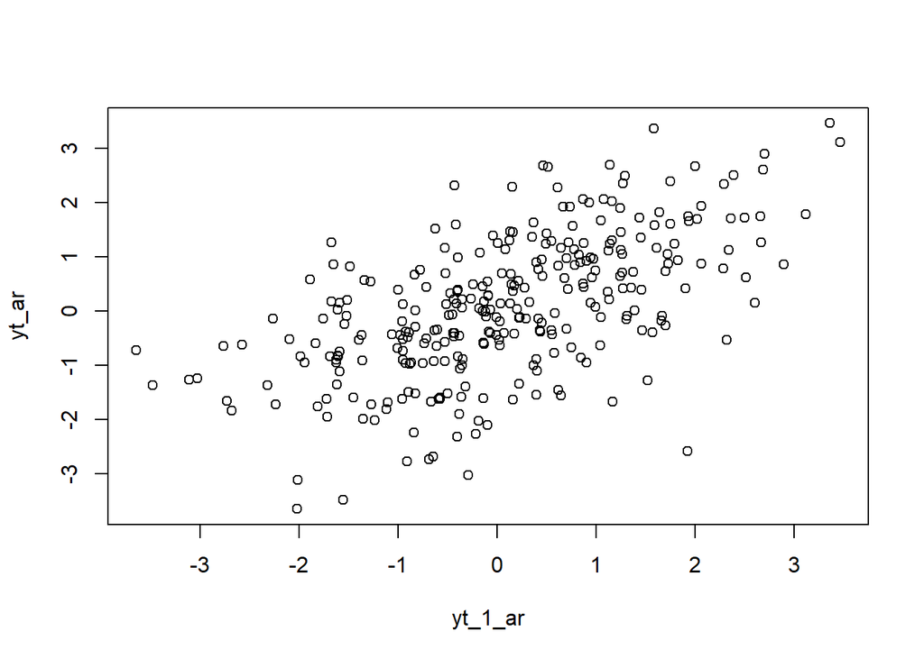

```r
plot(y=yt_ar,x=yt_1_ar)
```

### 3.3.2 Korelasi Yt dengan Yt-1

```r
cor(yt_ar,yt_1_ar)
```

```
## [1] 0.5888558
```

Menunjukkan adanya korelasi positif antara Yt dengan Yt-1 pada AR(2)

### 3.3.3 Yt dengan Yt-2

```r
yt_ar2 <- ar2[-c(1,2)]

yt_2_ar <- ar2[-c(299,300)]
```

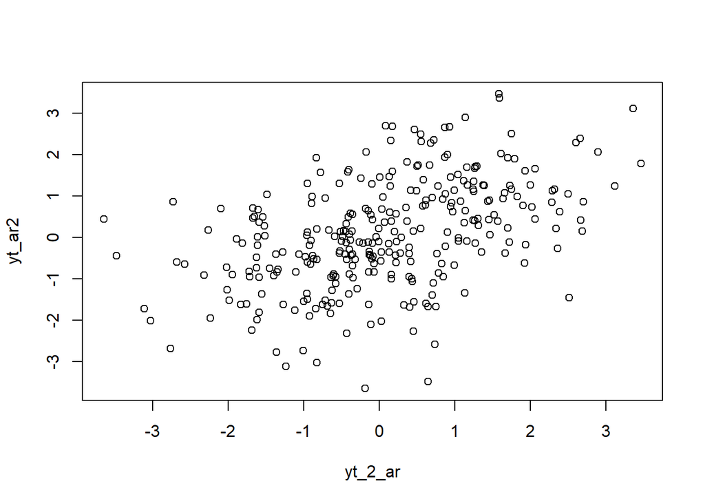

```r
plot(y = yt_ar2, x = yt_2_ar)
```

### 3.3.4 Korelasi Yt dengan Yt-2

```r
cor(yt_ar2, yt_2_ar)
```

```
## [1] 0.4648106
```

Menunjukkan adanya korelasi positif antara Yt dengan Yt-2 pada AR(2)

### 3.3.5 Yt dengan Yt-3

```r
yt_ar3 <- ar2[-c(1,2,3)]

yt_3_ar <- ar2[-c(298,299,300)]
```

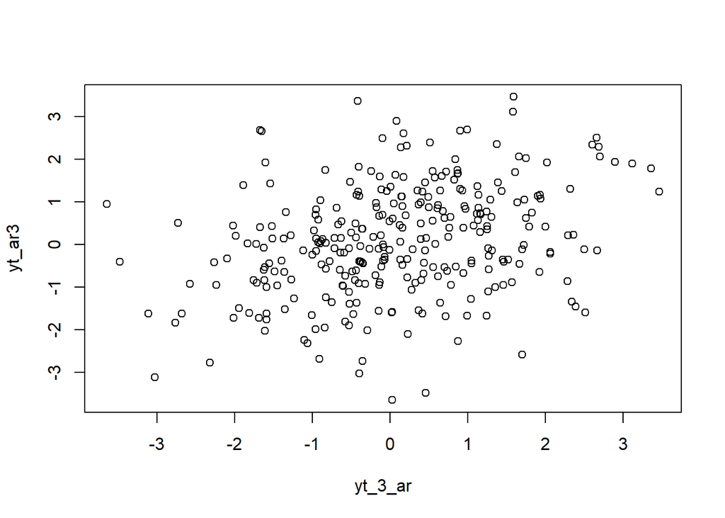

```r
plot(y = yt_ar3, x = yt_3_ar)
```

### 3.3.6 Korelasi Yt dengan Yt-3

```r
cor(yt_ar3, yt_3_ar)
```

```
## [1] 0.3157266
```

Menunjukkan adanya korelasi positif antara Yt dengan Yt-3 pada AR(2)

# 4 ARMA

## 4.1 Pembangkitan ARMA(2)

Akan dibangkitkan model ARMA(2) dengan $\phi_1 = 0,5$, $\phi_2 = 0,2$, $\theta_1 = 0,4$, dan $\theta_2 = 0.6$ sebanyak 300 data

### 4.1.1 Manual

```r
set.seed(140305)
n = length(wn)
phi1 = 0.5
phi2 = 0.2
theta1 = 0.4
theta2 = 0.6

y.arma <- numeric(n)
y.arma[1:2] <- wn[1:2]
for (i in 3:n){
  y.arma[i] <- phi1*y.arma[i-1] + phi2*y.arma[i-2] +
               theta1*wn[i-1] + theta2*wn[i-2] + wn[i]
}

y.arma
```

```
##   [1] -0.715449656 -0.500878274 -2.148543195 -1.153854968 -0.744732157
##   [6]  0.426076982 -0.084024207 -0.990302061 -1.113052779 -1.233968638
##  [11] -2.752277427 -2.539744609 -2.853089612 -3.951870357 -2.300698630
##  [16] -4.596862153 -3.293574388 -2.931137124 -2.951068638 -0.969920669
##  [21] -1.147189685 -2.080923147 -4.568839545 -3.385542114 -2.024708989
##  [26]  0.697693270  0.804827247  2.089575854  1.074145869  1.933933974
##  [31] -0.351691192  0.284918797  0.787627338  0.453353435  1.184863867
##  [36]  0.740756182 -1.025042074 -3.714238964 -3.695109495 -3.078928155
##  [41] -1.407103954 -0.283097354  0.307745268  1.532644186  1.921649158
##  [46]  2.319666687  1.479798558  2.189378250  1.485422861  2.383853547
##  [51]  3.302417473  3.410973268  1.838185502  1.149348737 -0.175227858
##  [56] -0.003163631 -2.201908448 -1.416693227 -0.767627018 -0.354417394
##  [61] -1.106253348 -1.281704460 -1.974832591 -1.067515836 -2.597528933
##  [66] -0.399190358 -0.939807687  1.723264614  0.541845837  2.088718174
##  [71]  1.960389789  2.689020824  1.843441277  0.630352780 -0.888225661
```

[output cut: 45 more lines]

### 4.1.2 Menggunakan `arima.sim`

```r
arma22 <- arima.sim(list(order=c(2,0,2), ar = c(0.5, 0.2), ma = c(0.4, 0.6)), n=300)
arma22
```

```
## Time Series:
## Start = 1
## End = 300
## Frequency = 1
##   [1]  2.090017921  1.074482877  1.934190891 -0.351495332  0.285068111
##   [6]  0.787741166  0.453440212  1.184930022  0.740806614 -1.025003627
##  [11] -3.714209653 -3.695087151 -3.078911121 -1.407090968 -0.283087455
##  [16]  0.307752815  1.532649939  1.921653544  2.319670031  1.479801107
##  [21]  2.189380193  1.485424342  2.383854676  3.302418334  3.410973925
##  [26]  1.838186002  1.149349118 -0.175227567 -0.003163409 -2.201908278
##  [31] -1.416693098 -0.767626920 -0.354417319 -1.106253291 -1.281704417
##  [36] -1.974832558 -1.067515811 -2.597528914 -0.399190343 -0.939807676
##  [41]  1.723264622  0.541845844  2.088718179  1.960389793  2.689020827
##  [46]  1.843441279  0.630352781 -0.888225660 -1.299671478 -3.601610509
##  [51] -3.153114422 -1.429509410 -0.132856501  3.380888300  3.120496648
```

[output cut: 49 more lines]

## 4.2 Karakteristik ARMA(2)

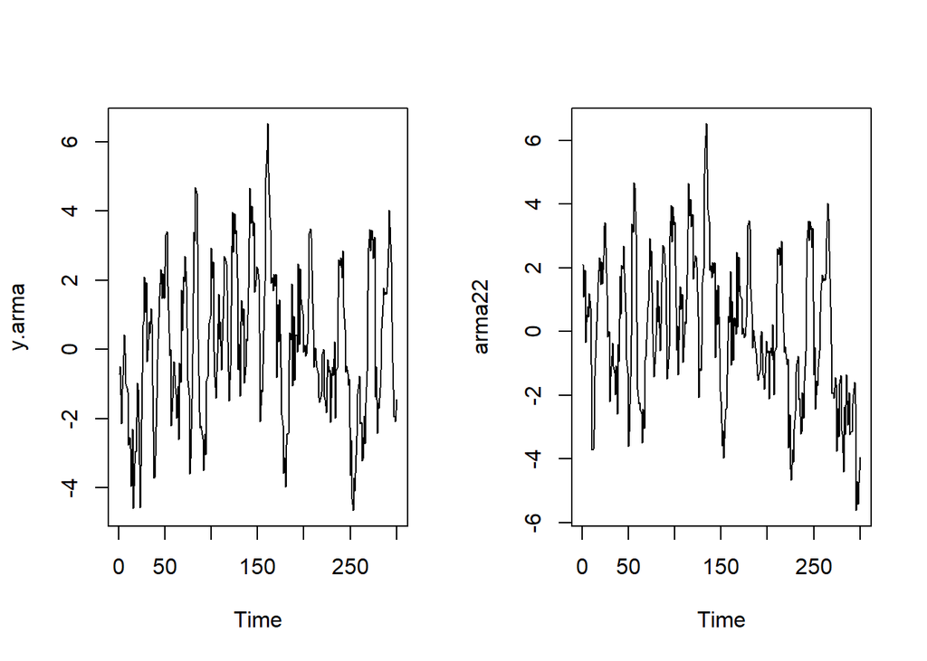

```r
par(mfrow = c(1, 2))
ts.plot(y.arma)
ts.plot(arma22)
```

```r
par(mfrow = c(1, 1))
```

Berdasarkan plot time series tersebut, terlihat bahwa model ARMA(2,2) cenderung stasioner dalam rataan.

### 4.2.1 ACF

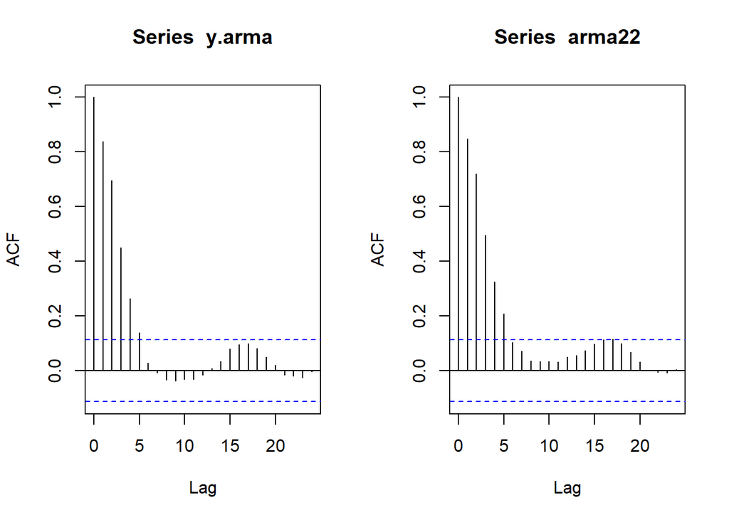

```r
par(mfrow = c(1, 2))
acf(y.arma)
acf(arma22)
```

```r
par(mfrow = c(1, 1))
```

Kedua plot diatas berbentuk tails-off, sesuai dengan teori yang ada

### 4.2.2 PACF

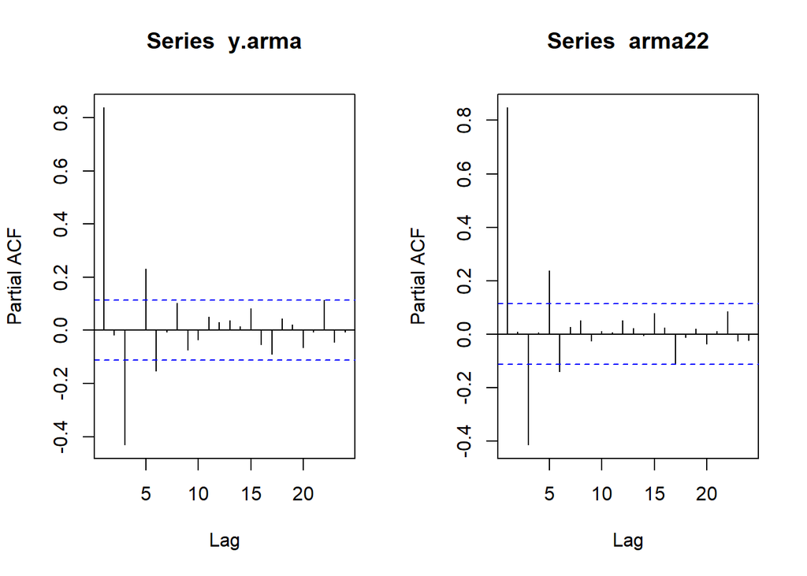

```r
par(mfrow = c(1, 2))
pacf(y.arma)
pacf(arma22)
```

```r
par(mfrow = c(1, 1))
```

Kedua plot diatas berbentuk tails-off, sesuai dengan teori yang ada

### 4.2.3 EACF

```r
TSA::eacf(y.arma)
```

```
## AR/MA
##   0 1 2 3 4 5 6 7 8 9 10 11 12 13
## 0 x x x x x o o o o o o  o  o  o
## 1 o x o o x o o o o o o  o  o  o
## 2 o x x o x x x o o o o  o  o  o
## 3 o x x x x x o o o o o  o  o  o
## 4 o x o o o o o o o o o  o  o  o
## 5 x x x o o o o o o o o  o  o  o
## 6 o x x x o o o o o o o  o  o  o
## 7 o x o x o o o o o o o  o  o  o
```

```r
TSA::eacf(arma22)
```

```
## AR/MA
##   0 1 2 3 4 5 6 7 8 9 10 11 12 13
## 0 x x x x x o o o o o o  o  o  o
## 1 o x o o x x o o o o o  o  o  o
## 2 o x o o o o o o o o o  o  o  o
## 3 o x o x o o o x o o o  o  o  o
## 4 o x x o x o o o o o o  o  o  o
## 5 x x x o x x o o o o o  o  o  o
## 6 o x x x x o x o o o o  o  o  o
## 7 o x x o x o x o o o o  o  o  o
```

## 4.3 Scatter Plot

### 4.3.1 Yt dengan Yt-1

```r
yt_arma <- arma22[-1]

yt_1_arma <- arma22[-300]
```

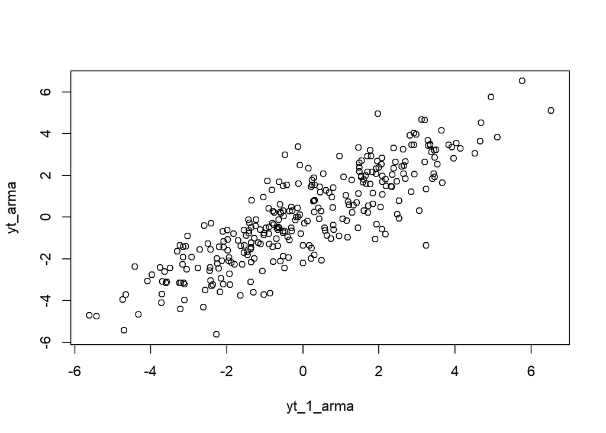

```r
plot(y = yt_arma, x = yt_1_arma)
```

### 4.3.2 Korelasi Yt dengan Yt-1

```r
cor(yt_arma, yt_1_arma)
```

```
## [1] 0.8529066
```

Menunjukkan adanya korelasi positif antara Yt dengan Yt-1 pada ARMA

### 4.3.3 Yt dengan Yt-2

```r
yt_arma2 = arma22[-c(1,2)]

yt_2_arma = arma22[-c(299,300)]
```

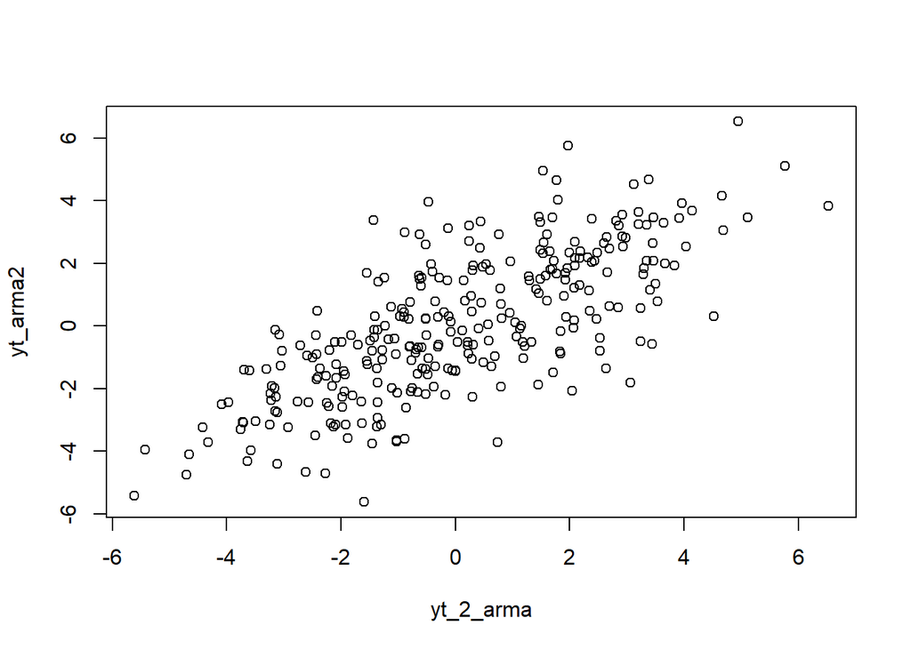

```r
plot(y = yt_arma2, x = yt_2_arma)
```

### 4.3.4 Korelasi Yt dengan Yt-2

```r
cor(yt_arma2, yt_2_arma)
```

```
## [1] 0.7306951
```

Menunjukkan adanya korelasi positif antara Yt dengan Yt-2 pada ARMA

### 4.3.5 Yt dengan Yt-3

```r
yt_arma3 = arma22[-c(1,2,3)]

yt_3_arma = arma22[-c(298,299,300)]
```

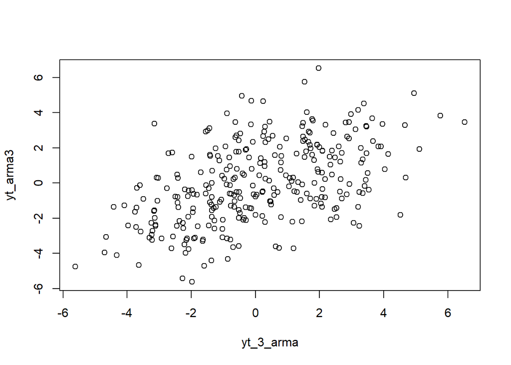

```r
plot(y = yt_arma3, x = yt_3_arma)
```

### 4.3.6 Korelasi Yt dengan Yt-3

```r
cor(yt_arma3, yt_3_arma)
```

```
## [1] 0.5081874
```

Menunjukkan adanya korelasi positif antara Yt dengan Yt-3 pada ARMA